# 9.2: Therapeutic touch

## Introduction

This is the “Therapeutic touch” example in Section 9.2 of Kruschke.

## Preliminaries

Load necessary packages:

```r
library(tidyverse)
library(rstan)
library(shinystan)
library(bayesplot)
library(GGally)
```

Set Stan to save compiled code.

```r
rstan_options(auto_write = TRUE)
```

Set Stan to use parallel processing where possible.

```r
options(mc.cores = parallel::detectCores())
```

## Data

First we import the data. (Make sure the file “TherapeuticTouchData.csv” is in your project directory.)

```r
tt_data <- read_csv("TherapeuticTouchData.csv")
tt_data
```

| y | s |
| --- | --- |
| 1 | S01 |
| 0 | S01 |
| 0 | S01 |
| 0 | S01 |
| 0 | S01 |
| 0 | S01 |
| 0 | S01 |
| 0 | S01 |
| 0 | S01 |
| 0 | S01 |

[output cut: 270 more lines]

In order to use the same Stan code as before, we’ll need to aggregate the data so that it shows the number of successes for each subject (instead of the raw successes and failures).

```r
tt_data_sum <- tt_data %>%
    group_by(s) %>%
    summarize(n = n(), y_agg = sum(y))
tt_data_sum
```

| s | n | y_agg |
| --- | --- | --- |
| S01 | 10 | 1 |
| S02 | 10 | 2 |
| S03 | 10 | 3 |
| S04 | 10 | 3 |
| S05 | 10 | 3 |
| S06 | 10 | 3 |
| S07 | 10 | 3 |
| S08 | 10 | 3 |
| S09 | 10 | 3 |
| S10 | 10 | 3 |

[output cut: 18 more lines]

```r
S <- NROW(tt_data_sum) # number of subjects
N <- tt_data_sum$n # number of trials for each subject
y <- tt_data_sum$y_agg # number of successes for each subject
stan_data <- list(S = S, N = N, y = y)
```

## Stan code

Note that because we were careful to make the Stan code as generic as possible, we don’t have the change a thing to change it from 2 manufactured coins to therapeutic touch practitioners. (All we change below is the name of the `output.var` in the code chunk header.)

```stan
data {
    int<lower = 0> S;
    int<lower = 0> N[S];
    int<lower = 0> y[S];
}
transformed data {
    real<lower = 0> A_omega;
    real<lower = 0> B_omega;
    real<lower = 0> S_kappa;
    real<lower = 0> R_kappa;

    A_omega = 2;
    B_omega = 2;
    S_kappa =  0.01;
    R_kappa =  0.01;
}
parameters {
    real<lower = 0, upper = 1> omega;
    real<lower = 0> kappa_minus_two;
    real<lower = 0, upper = 1> theta[S];
}
transformed parameters {
    real<lower = 2> kappa;
    real<lower = 0> a;
    real<lower = 0> b;

    kappa = kappa_minus_two + 2;
    a = omega * (kappa - 2) + 1;
    b = (1 - omega) * (kappa - 2) + 1;
}
model {
    omega ~ beta(A_omega, B_omega);
    kappa_minus_two ~ gamma(S_kappa, R_kappa);
    theta ~ beta(a, b);
    y ~ binomial(N, theta);
}
generated quantities {
    int<lower = 0> y_rep[S];

    for (s in 1:S) {
        y_rep[s] = binomial_rng(N[s], theta[s]);
    }
}
```

## Sampling from the model

```r
set.seed(11111)
fit_tt <- sampling(tt, data = stan_data, refresh = 0)
```

```
There were 1 divergent transitions after warmup. Increasing adapt_delta above 0.8 may help. See
http://mc-stan.org/misc/warnings.html#divergent-transitions-after-warmupThere were 1 chains where the estimated Bayesian Fraction of Missing Information was low. See
http://mc-stan.org/misc/warnings.html#bfmi-lowExamine the pairs() plot to diagnose sampling problems
```

With a lot of data informing the value of $\kappa$, we don’t have too much trouble with divergences.

## Diagnosing the model

There are now 28 values of $\theta$. Rather than check them all, we’ll just look at a few of them.

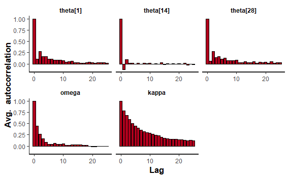

```r
plot(fit_tt, plotfun = "ac",
     pars = c("theta[1]", "theta[14]", "theta[28]",
              "omega", "kappa"))
```

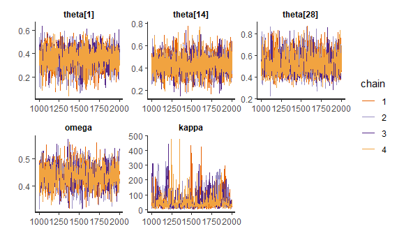

```r
plot(fit_tt, plotfun = "trace",
     pars = c("theta[1]", "theta[14]", "theta[28]",
              "omega", "kappa"))
```

## Summarizing the model

```r
fit_tt
```

```
Inference for Stan model: stan-24c0311249f3.
4 chains, each with iter=2000; warmup=1000; thin=1;
post-warmup draws per chain=1000, total post-warmup draws=4000.

                   mean se_mean    sd    2.5%     25%     50%
omega              0.44    0.00  0.04    0.37    0.41    0.43
kappa_minus_two   57.15    4.00 58.16    6.71   19.84   37.46
theta[1]           0.36    0.00  0.09    0.17    0.31    0.37
theta[2]           0.38    0.00  0.08    0.21    0.33    0.39
theta[3]           0.41    0.00  0.08    0.24    0.36    0.41
theta[4]           0.41    0.00  0.08    0.24    0.36    0.41
theta[5]           0.41    0.00  0.08    0.24    0.36    0.41
theta[6]           0.41    0.00  0.08    0.24    0.36    0.41
theta[7]           0.41    0.00  0.08    0.24    0.36    0.41
theta[8]           0.41    0.00  0.08    0.25    0.36    0.41
theta[9]           0.41    0.00  0.08    0.24    0.36    0.41
theta[10]          0.41    0.00  0.08    0.24    0.36    0.41
theta[11]          0.43    0.00  0.08    0.28    0.38    0.43
theta[12]          0.43    0.00  0.08    0.27    0.38    0.43
theta[13]          0.43    0.00  0.08    0.27    0.38    0.43
theta[14]          0.43    0.00  0.08    0.28    0.38    0.43
theta[15]          0.43    0.00  0.08    0.28    0.38    0.43
theta[16]          0.45    0.00  0.08    0.31    0.40    0.45
theta[17]          0.46    0.00  0.08    0.30    0.40    0.45
theta[18]          0.45    0.00  0.08    0.31    0.40    0.45
theta[19]          0.45    0.00  0.08    0.30    0.40    0.45
theta[20]          0.45    0.00  0.08    0.30    0.40    0.45
theta[21]          0.46    0.00  0.08    0.30    0.40    0.45
theta[22]          0.45    0.00  0.08    0.30    0.40    0.45
theta[23]          0.47    0.00  0.08    0.32    0.42    0.47
theta[24]          0.48    0.00  0.08    0.33    0.42    0.47
theta[25]          0.50    0.00  0.08    0.35    0.44    0.49
theta[26]          0.50    0.00  0.09    0.36    0.44    0.49
theta[27]          0.50    0.00  0.09    0.35    0.44    0.49
theta[28]          0.52    0.00  0.09    0.37    0.46    0.51
kappa             59.15    4.00 58.16    8.71   21.84   39.46
a                 25.98    1.76 25.63    3.80    9.70   17.35
b                 33.17    2.24 32.74    4.81   12.13   21.99
y_rep[1]           3.61    0.04  1.71    1.00    2.00    4.00
y_rep[2]           3.85    0.03  1.69    1.00    3.00    4.00
```

[output cut: 80 more lines]

```
y_rep[20]          6.00    8.00  4319 1.00
y_rep[21]          6.00    8.00  3941 1.00
y_rep[22]          6.00    8.00  4126 1.00
y_rep[23]          6.00    8.00  3806 1.00
y_rep[24]          6.00    8.00  3499 1.00
y_rep[25]          6.00    9.00  2743 1.00
y_rep[26]          6.00    8.00  3265 1.00
y_rep[27]          6.00    9.00  2826 1.00
y_rep[28]          6.00    9.00  2264 1.00
lp__            -193.15 -177.62   211 1.01

Samples were drawn using NUTS(diag_e) at Tue May 28 11:11:28 2019.
For each parameter, n_eff is a crude measure of effective sample size,
and Rhat is the potential scale reduction factor on split chains (at
convergence, Rhat=1).
```

## Visualizing the model

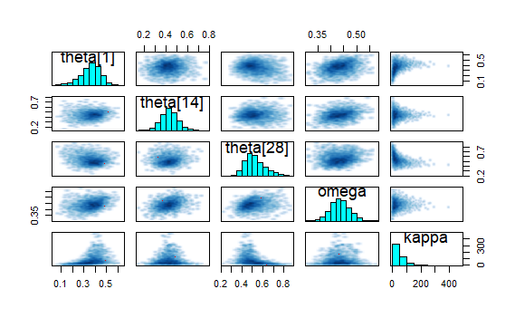

```r
pairs(fit_tt, pars = c("theta[1]", "theta[14]", "theta[28]",
                       "omega", "kappa"))
```

```
ci_level: 0.8 (80% intervals)
outer_level: 0.95 (95% intervals)
```

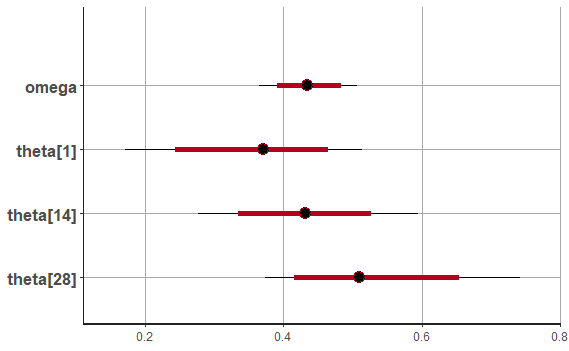

```r
plot(fit_tt, pars = c("omega", "theta[1]", "theta[14]", "theta[28]"))
```

```
ci_level: 0.8 (80% intervals)
outer_level: 0.95 (95% intervals)
```

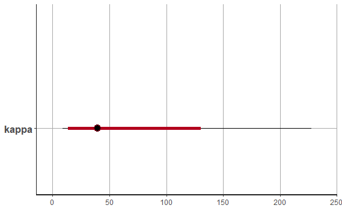

```r
plot(fit_tt, pars = "kappa")
```

## Examining the prior

```stan
data {
    int<lower = 0> S;
    int<lower = 0> N[S];
    int<lower = 0> y[S];
}
transformed data {
    real<lower = 0> A_omega;
    real<lower = 0> B_omega;
    real<lower = 0> S_kappa;
    real<lower = 0> R_kappa;

    A_omega = 2;
    B_omega = 2;
    S_kappa =  0.01;
    R_kappa =  0.01;
}
parameters {
    real<lower = 0, upper = 1> omega;
    real<lower = 0> kappa_minus_two;
    real<lower = 0, upper = 1> theta[S];
}
transformed parameters {
    real<lower = 2> kappa;
    real<lower = 0> a;
    real<lower = 0> b;

    kappa = kappa_minus_two + 2;
    a = omega * (kappa - 2) + 1;
    b = (1 - omega) * (kappa - 2) + 1;
}
model {
    omega ~ beta(A_omega, B_omega);
    kappa_minus_two ~ gamma(S_kappa, R_kappa);
    theta ~ beta(a, b);
//    y ~ binomial(N, theta);
}
```

```r
set.seed(11111)
fit_tt_prior <- sampling(tt_prior, data = stan_data, refresh = 0,
                         control = list(adapt_delta = 0.999,
                                        max_treedepth = 15))
```

```
There were 2 divergent transitions after warmup. Increasing adapt_delta above 0.999 may help. See
http://mc-stan.org/misc/warnings.html#divergent-transitions-after-warmupExamine the pairs() plot to diagnose sampling problems
```

```r
fit_tt_prior
```

```
Inference for Stan model: stan-24c057aa1c72.
4 chains, each with iter=2000; warmup=1000; thin=1;
post-warmup draws per chain=1000, total post-warmup draws=4000.

                  mean se_mean   sd   2.5%    25%    50%    75%
omega             0.50    0.00 0.22   0.09   0.34   0.50   0.67
kappa_minus_two   0.03    0.01 0.23   0.00   0.00   0.00   0.00
theta[1]          0.51    0.00 0.29   0.04   0.26   0.50   0.76
theta[2]          0.50    0.00 0.29   0.03   0.26   0.50   0.74
theta[3]          0.50    0.00 0.29   0.03   0.25   0.50   0.74
theta[4]          0.50    0.00 0.29   0.02   0.25   0.50   0.74
theta[5]          0.50    0.00 0.29   0.03   0.26   0.51   0.75
theta[6]          0.50    0.00 0.29   0.03   0.24   0.49   0.75
theta[7]          0.50    0.00 0.29   0.02   0.26   0.50   0.74
theta[8]          0.50    0.00 0.29   0.03   0.25   0.49   0.74
theta[9]          0.50    0.00 0.29   0.03   0.24   0.50   0.75
theta[10]         0.50    0.00 0.29   0.03   0.24   0.50   0.76
theta[11]         0.50    0.00 0.29   0.03   0.25   0.50   0.75
theta[12]         0.50    0.00 0.28   0.03   0.25   0.50   0.75
theta[13]         0.50    0.00 0.29   0.03   0.25   0.51   0.76
theta[14]         0.49    0.00 0.29   0.02   0.23   0.49   0.74
theta[15]         0.51    0.00 0.29   0.03   0.26   0.51   0.76
theta[16]         0.51    0.00 0.29   0.03   0.25   0.51   0.75
theta[17]         0.50    0.00 0.29   0.02   0.24   0.49   0.75
theta[18]         0.50    0.00 0.29   0.03   0.26   0.50   0.74
theta[19]         0.49    0.00 0.29   0.02   0.24   0.49   0.74
theta[20]         0.50    0.00 0.29   0.03   0.25   0.51   0.75
theta[21]         0.50    0.00 0.29   0.03   0.25   0.50   0.76
theta[22]         0.50    0.00 0.29   0.02   0.24   0.50   0.75
theta[23]         0.50    0.00 0.29   0.03   0.24   0.50   0.76
theta[24]         0.50    0.00 0.29   0.02   0.24   0.50   0.76
theta[25]         0.51    0.00 0.29   0.03   0.26   0.51   0.76
theta[26]         0.50    0.00 0.29   0.02   0.24   0.50   0.74
theta[27]         0.51    0.00 0.28   0.03   0.26   0.51   0.75
theta[28]         0.51    0.00 0.28   0.03   0.27   0.51   0.75
kappa             2.03    0.01 0.23   2.00   2.00   2.00   2.00
a                 1.01    0.00 0.12   1.00   1.00   1.00   1.00
b                 1.01    0.00 0.12   1.00   1.00   1.00   1.00
lp__            -60.01    0.13 4.71 -69.94 -62.95 -59.80 -56.76
                 97.5% n_eff Rhat
```

[output cut: 24 more lines]

```
theta[23]         0.97  5470    1
theta[24]         0.97  5010    1
theta[25]         0.97  5503    1
theta[26]         0.97  5886    1
theta[27]         0.97  6137    1
theta[28]         0.98  4708    1
kappa             2.23   730    1
a                 1.11   744    1
b                 1.10   826    1
lp__            -51.70  1292    1

Samples were drawn using NUTS(diag_e) at Tue May 28 11:14:31 2019.
For each parameter, n_eff is a crude measure of effective sample size,
and Rhat is the potential scale reduction factor on split chains (at
convergence, Rhat=1).
```

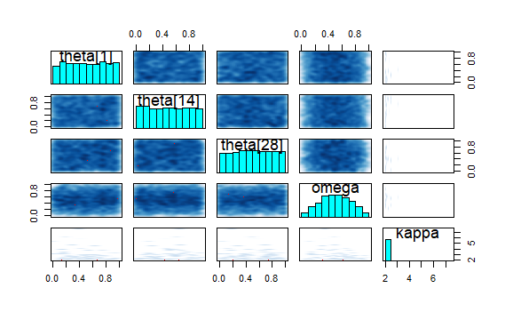

```r
pairs(fit_tt_prior, pars = c("theta[1]", "theta[14]", "theta[28]",
                             "omega", "kappa"))
```

```
ci_level: 0.8 (80% intervals)
outer_level: 0.95 (95% intervals)
```

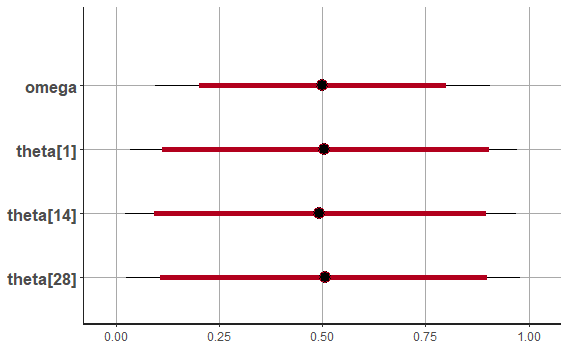

```r
plot(fit_tt_prior, pars = c("omega",
                            "theta[1]", "theta[14]", "theta[28]"))
```

```
ci_level: 0.8 (80% intervals)
outer_level: 0.95 (95% intervals)
```

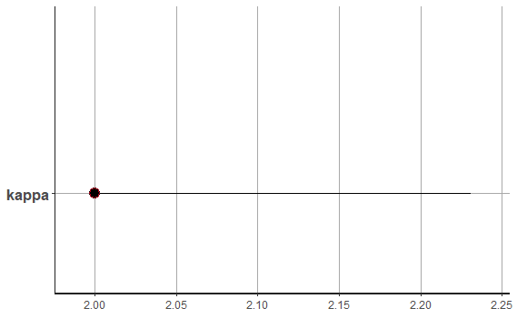

```r
plot(fit_tt_prior, pars = "kappa")
```

## Posterior predictive check

Extract predicted values:

```r
samples_tt <- extract(fit_tt)
y_rep <- samples_tt$y_rep
```

Graph values of $y$ against summaries of $y_{rep}$.

(The `ppc_stat` function requires a matrix as input, so we have to convert the single columns of values in `y_rep[, 1]` to a 4000 by 1 matrix.)

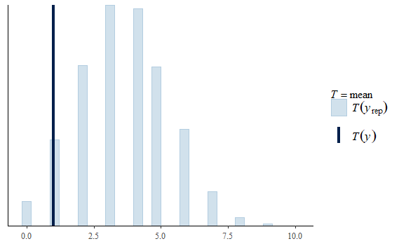

```r
ppc_stat(y[1], as.matrix(y_rep[ , 1]))
```

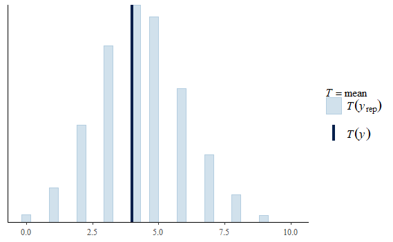

```r
ppc_stat(y[14], as.matrix(y_rep[ , 14]))
```

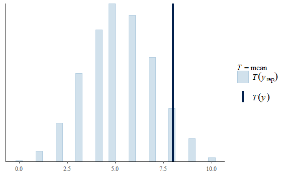

```r
ppc_stat(y[28], as.matrix(y_rep[ , 28]))
```

The $x$ value in the graph below identify the subjects.

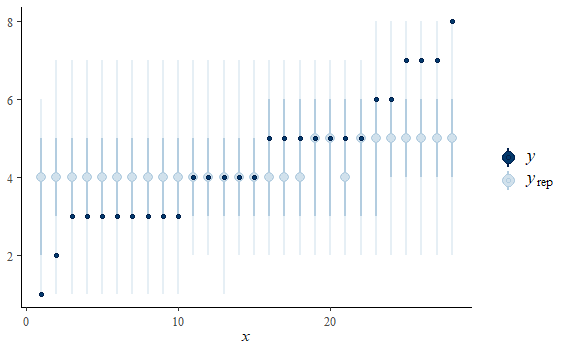

```r
ppc_intervals(y, y_rep)
```

We can also plot comparisons between selected values of $\theta$ as was done in the book.

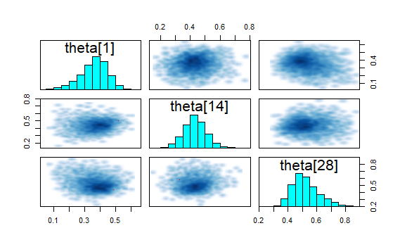

```r
pairs(fit_tt, pars = c("theta[1]", "theta[14]", "theta[28]"))
```

The easiest thing to do is just extract the relevant columns by hand:

```r
theta_diff_28_1 <- samples_tt$theta[ , 28] - samples_tt$theta[ , 1]
theta_diff_14_1 <- samples_tt$theta[ , 14] - samples_tt$theta[ , 1]
theta_diff_28_14 <- samples_tt$theta[ , 28] - samples_tt$theta[ , 14]

theta_diff_df <- bind_cols(theta_diff_28_1 = theta_diff_28_1,
                           theta_diff_14_1 = theta_diff_14_1,
                           theta_diff_28_14 = theta_diff_28_14)
```

We use the `ggpairs` functions from the `GGally` package.

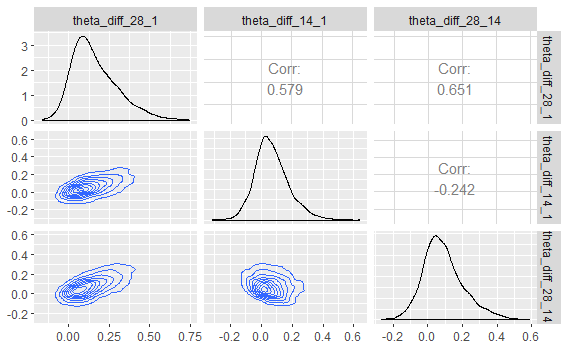

```r
ggpairs(theta_diff_df, lower = list(continuous = "density"))
```

## ShinyStan

Run the following code from the Console:

```
launch_shinystan(fit_tt)
```